# 7-26 RSFT 实验

# RSFT 实验

这个文档记录汇报为了双向上采样而加入RSFT论文的情况

# 1. RSFT复现

## 现有一维 RSFT 模型

设上采样后的 SAR 复回波为

$$s_{\uparrow}(\tau,\eta)\in\mathbb{C},$$

其中：

- $\tau$ 为距离快时间；
- $\eta$ 为方位慢时间。

现有距离向 RSFT 可写为

$$u_{\mathrm{RSFT}}(\tau)
=A_u\exp\left[j\left(2\pi f_r\tau+\phi_0\right)\right],$$

其中：

- $A_u$ 为阈值幅度；
- $f_r$ 为距离阈值频率；
- $\phi_0$ 为初始相位。

阈值幅度按照信号—阈值比 STR 设定：

$$A_u
=\frac{\hat{\sigma}}{10^{\mathrm{STR}/20}},$$

其中

$$\hat{\sigma}
=\sqrt{\frac{2}{\pi}}\operatorname{mean}\left(|s_{\uparrow}|\right).$$

在二维回波矩阵上，现有 RSFT 实际为

$$U_{\mathrm{RSFT}}(m,n)
=A_u\exp\left[j\left(2\pi f_r\tau_m+\phi_0\right)\right],$$

即同一条距离阈值向量沿全部方位脉冲重复。

# 2 RSFT加入双向上采样的结果

由于赵博老师的论文中，RSFT阈值是生成一条距离向的向量，方位向由相位控制。本质上是一维距离单频阈值，其形式为
$$u(\tau)=A\exp(j(2\pi
f_0\tau+\phi))$$
阈值仅沿距离快时间方向变化；其所谓 2-D varying strategy 并非引入方位单频项，而是在不同慢时间脉冲之间改变距离单频阈值的初始相位 1D模式就是相位=0，2D模式就是相位在方位向上服从$U(0, 2\pi)$

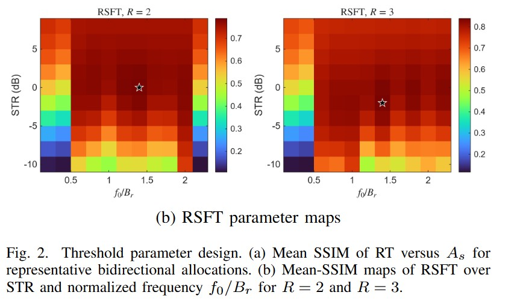

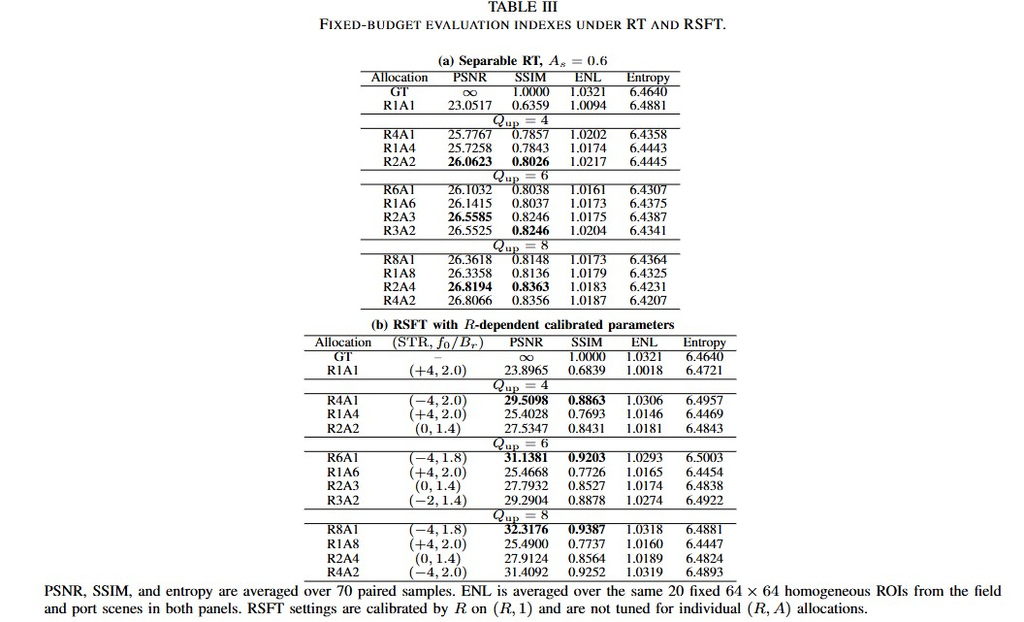

可以看出原版的RSFT是只对距离向上采样敏感的。和A的值无关，R的值越高，对应的1bit图效果越好

所以我想针对我们的双向上采样的特点，把RSFT扩展到2维。所以有了一下的2D RSFT：

# 3 2D-RSFT

## 1. 研究动机

当前 RSFT（Range Single-Frequency Threshold）在距离快时间方向生成单频复阈值，并沿方位方向重复。因此，RSFT 的谐波搬移和频谱容纳机制主要作用于距离频谱。

在固定总上采样预算

$$Q_{\mathrm{up}}=R\times A$$

下，R4A1 与 R2A2 虽然具有相同的总预算，但对现有 RSFT 而言，真正直接增强阈值频谱搬移能力的是距离倍率 $R$。因此，R4A1 实际上相当于使用比 R2A2 更大的距离频谱扩展空间，容易天然取得更高的成像指标。

为使阈值结构与双向距离—方位上采样相匹配，可以分别在距离方向和方位方向构造单频相位向量，并采用与 SplitRT 相同的“相位广播相加”方式生成二维阈值矩阵。该方案记为 **2D RSFT**。

## 2. 2D RSFT 的数学形式

分别构造距离向和方位向单频相位：

$$\phi_r(\tau)=2\pi f_r\tau,$$

$$\phi_a(\eta)=2\pi f_a\eta,$$

其中 $f_a$ 为方位慢时间方向的阈值频率。

将两个方向的相位广播相加，得到二维阈值：

该式也可写为两个单位模复指数的乘积：

$$U_{\mathrm{2D\text{-}RSFT}}(\tau,\eta)
=A_u
\exp(j2\pi f_r\tau)
\exp(j2\pi f_a\eta)
\exp(j\phi_0).$$

离散形式为

其中：

$$\tau_m
=\frac{m-m_0}{F_{s,\uparrow}},
\qquad
F_{s,\uparrow}=R F_s,$$

$$\eta_n
=\frac{n-n_0}{\mathrm{PRF}_{\uparrow}},
\qquad
\mathrm{PRF}_{\uparrow}=A\,\mathrm{PRF}.$$

这里 $m_0$ 和 $n_0$ 为距离向、方位向离散网格中心位置。

由于2D RSFT的公式内部有3个可调参数：$A$, $f_a$, $f_r$ ，而且在: - $f_a=0$, $f_r\neq0$ 下，退化为赵博老师的距离向RSFT - $f_a\neq0$, $f_r=0$ 下，退化为国离老师的方位向RSFT - 都不为0时则将这个时间波动阈值扩展到二维空间. 整体思路是类似我构造Split RT的思路.就是加入的是二维相位 代码实现:

```
function [U, sigma_hat, threshold_amplitude] = buildRSFT2DThreshold( ...
        signal_up, S60, range_q, azimuth_q, ...
        STR_dB, fr_over_Br, fa_over_Ba, ...
        azimuth_bandwidth_Hz, initial_phase)

% 生成恒模二维单频阈值。
%
% 相位采用距离相位与方位相位相加，而不是两个复阈值直接相加：
% phi(m,n) = 2*pi*fr*tau_m + 2*pi*fa*eta_n + phi0
%
% 上采样后等效采样率：
% Fs_r_up = R * Fs
% PRF_up = A * PRF

arguments
    signal_up
    S60
    range_q (1, 1) double {mustBePositive}
    azimuth_q (1, 1) double {mustBePositive}
    STR_dB (1, 1) double
    fr_over_Br (1, 1) double {mustBeNonnegative}
    fa_over_Ba (1, 1) double {mustBeNonnegative}
    azimuth_bandwidth_Hz (1, 1) double {mustBePositive}
    initial_phase (1, 1) double = 0
end

[Nr_up, Na_up] = size(signal_up);
Fs_range_up = range_q * S60.Fs;
PRF_up = azimuth_q * S60.prf;

fast_time_rel = ((0:Nr_up - 1).' - floor(Nr_up / 2)) / Fs_range_up;
slow_time_rel = ((0:Na_up - 1) - floor(Na_up / 2)) / PRF_up;

fr_Hz = fr_over_Br * S60.B;
fa_Hz = fa_over_Ba * azimuth_bandwidth_Hz;

sigma_hat = sqrt(2 / pi) * mean(abs(signal_up(:)));
threshold_amplitude = sigma_hat / (10 ^ (STR_dB / 20));

phase_range = 2 * pi * fr_Hz * fast_time_rel;
phase_azimuth = 2 * pi * fa_Hz * slow_time_rel;

U = threshold_amplitude * exp(1i * (phase_range + phase_azimuth + initial_phase));

end
```

# 4 2D RSFT实验

## 4.1 参数定义

2D RSFT 至少包含三个核心参数：

$$\mathrm{STR_db},
\qquad
\frac{f_r}{B_r},
\qquad
\frac{f_a}{B_a},$$

其中：

- $B_r$ 为距离 LFM 信号带宽；
- $B_a$ 为有效方位多普勒带宽。

定义

$$f_r=\alpha_r B_r,
\qquad
f_a=\alpha_a B_a,$$

其中

$$\alpha_r=\frac{f_r}{B_r},
\qquad
\alpha_a=\frac{f_a}{B_a}.$$

必须满足离散采样约束：

$$|f_r|<\frac{R F_s}{2},$$

$$|f_a|<\frac{A\,\mathrm{PRF}}{2}.$$
我对三个可调参数做了完整的参数搜索, 上采样的Q值搜索范围`Q=1-10` 每个Q内有做了完整的q排列测试,比如Q=8,则有R1A8, R2A4, R4A2, R8A1. $STR_dB = -10:4:10$ $\frac{f_r}{B_r} = 0:0.4:2.4$ $\frac{f_r}{B_r} = 0:0.4:2.4$

% 每轮围绕当前最优点细化；最多两轮，避免一次高密度三维全网格。 $STR_offsets = -2:1:2;$ $fine\_\frac{f_r}{B_r}\_offsets = -0.2:0.1:0.2;$ $fine\_\frac{f_a}{B_a}\_offsets = -0.2:0.1:0.2;$ 这里的offsets的意思就是在第一轮粗搜索找到的最优参数为核心进行左右搜索

## 4.2 实验结果

最后的结果如下:

| GroupName | Best_STRdB | Best_FrOverBr | Best_FaOverBa | PSNR_mean | SSIM_mean |
| --- | --- | --- | --- | --- | --- |
| R1A1 | 4 | 2.0 | 0.0 | 23.9541 | 0.688245 |
| R1A2 | 0 | 1.9 | 1.3 | 26.2935 | 0.797727 |
| R2A1 | 0 | 1.4 | 0.7 | 26.1939 | 0.792795 |
| R1A3 | -2 | 2.0 | 1.4 | 27.9327 | 0.851550 |
| R3A1 | -1 | 2.1 | 2.0 | 27.6118 | 0.843565 |
| **R1A4** | **-3** | **0.0** | **1.8** | **29.4150** | **0.890179** |
| **R2A2** | **-2** | **0.6** | **1.3** | **28.6958** | **0.874137** |
| **R4A1** | **-3** | **2.0** | **1.2** | **29.4294** | **0.889216** |
| **R1A5** | **-4** | **1.2** | **1.5** | **30.2844** | **0.905558** |
| **R5A1** | **-4** | **1.5** | **0.8** | **30.2706** | **0.906880** |
| **R1A6** | **-4** | **1.2** | **1.6** | **30.9650** | **0.919475** |
| **R2A3** | **-3** | **2.0** | **1.5** | **30.3742** | **0.910919** |
| **R3A2** | **-4** | **0.8** | **1.3** | **30.5266** | **0.910629** |
| **R6A1** | **-4** | **1.8** | **0.7** | **31.0641** | **0.921077** |
| **R1A7** | **-5** | **0.2** | **1.4** | **31.9399** | **0.932436** |
| **R7A1** | **-5** | **1.6** | **0.5** | **31.6894** | **0.929954** |
| **R1A8** | **-5** | **1.8** | **1.5** | **32.4656** | **0.940843** |
| **R2A4** | **-4** | **2.0** | **1.8** | **31.8710** | **0.934356** |
| **R4A2** | **-4** | **2.0** | **0.6** | **31.8274** | **0.933907** |
| **R8A1** | **-5** | **1.8** | **2.3** | **32.4735** | **0.940437** |
| **R1A9** | **-5** | **1.6** | **1.5** | **32.9947** | **0.947012** |
| **R3A3** | **-4** | **0.8** | **1.6** | **32.3228** | **0.940753** |
| **R9A1** | **-5** | **1.6** | **2.0** | **32.9179** | **0.946294** |
| **R1A10** | **-5** | **0.6** | **1.6** | **33.3859** | **0.951786** |
| **R2A5** | **-4** | **0.2** | **1.4** | **32.5821** | **0.944086** |
| **R5A2** | **-4** | **2.0** | **2.0** | **32.3956** | **0.942488** |
| **R10A1** | **-6** | **1.6** | **0.5** | **33.4636** | **0.951350** |

从表中可以直观看出：

1. 双向组的最优参数均满足：
   $$f_r\neq0,\quad f_a\neq0$$
   因此 2D RSFT 并没有退化为 Zhao 式纯距离 RSFT 或 Nie 式纯方位单频阈值。
2. 但是在相同预算：
   $$Q=RA$$
   下，单向组仍获得更高 PSNR/SSIM。

因此该结果支持如下现象：

> **二维阈值结构本身能够提升单比特 SAR 成像质量，但二维阈值频率结构并不必然导致二维上采样分配最优；在 2D RSFT 下，固定预算仍倾向集中于单一采样维度。**